### Udacity/ Data Analysis With R

### PS1: Explore One Variable: “Cholesterol in blood in female population”

### About Dataset

Definition and explanations:

1. Indicator Name: TC female (mmol/L), age standardized mean.
2. Definition of the indicator: The mean TC (Total Cholesterol) of the female population, counted in mmol per L; this mean is calculated as if each country has the same age composition as the world population.
3. Source organization(s): School of Public Health, Imperial College London
4. Link to source organization: http://www.imperial.ac.uk/
5. Complete reference: MRC-HPA Centre for Environment and Health
6. Link to complete reference: http://www.imperial.ac.uk/medicine/globalmetabolics/
7. Dataset consists data of the female populations of 199 countries (1980 through 2008).
8. Gapminder Data: https://www.gapminder.org/
9. Auxiliary data: https://github.com/lukes/ISO-3166-Countries-with-Regional-Codes/tree/master/all

### Overview of the Data

Using the Cholesterol (fat) in blood in female population Gapminder data set, some exploratory graphics were built to understand the trend of this indicator.

Loading libraries:

```r
library(gridExtra)
library(ggplot2)
```

Loading csv data file:

```r
dt <- read.csv('Indicator_TC_female_ASM.csv', header = T,  check.names = F)
```

### Cleaning and Re-shaping Data

Quick view of the statistics:

```r
dim(dt)
```

```
## [1] 199  30
```

```r
str(dt)
```

```
## 'data.frame':    199 obs. of  30 variables:
##  $ TC  : Factor w/ 199 levels "Afghanistan",..: 1 2 3 4 5 6 7 8 9 10 ...
##  $ 1980: num  4.64 5.04 4.98 6.13 4.79 ...
##  $ 1981: num  4.64 5.04 4.98 6.1 4.77 ...
##  $ 1982: num  4.63 5.03 4.97 6.07 4.75 ...
##  $ 1983: num  4.63 5.03 4.98 6.04 4.73 ...
##  $ 1984: num  4.62 5.02 4.98 6.01 4.72 ...
##  $ 1985: num  4.61 5.02 4.98 5.98 4.71 ...
##  $ 1986: num  4.61 5.01 4.97 5.95 4.69 ...
##  $ 1987: num  4.6 5.01 4.97 5.92 4.68 ...
##  $ 1988: num  4.58 5 4.96 5.89 4.67 ...
##  $ 1989: num  4.57 5 4.96 5.86 4.67 ...
##  $ 1990: num  4.55 4.99 4.95 5.84 4.65 ...
##  $ 1991: num  4.53 4.97 4.94 5.81 4.64 ...
##  $ 1992: num  4.51 4.95 4.93 5.78 4.63 ...
```

[output cut: 16 more lines]

Changing the first column name:

```r
names(dt)[1] <- c("Country")
```

Loading auxiliary data set containing country names and the region /continent/ to which each belongs:

```r
country_region <- read.csv('all.csv', header = T,  check.names = F, na.strings=c("", "NA"))
```

```r
dim(country_region)
```

```
## [1] 249   9
```

```r
str(country_region)
```

```
## 'data.frame':    249 obs. of  9 variables:
##  $ name           : Factor w/ 249 levels "\xcc\xc9land Islands",..: 2 1 3 4 5 6 7 8 9 10 ...
##  $ alpha-2        : Factor w/ 248 levels "AD","AE","AF",..: 3 15 6 62 11 1 8 5 9 4 ...
##  $ alpha-3        : Factor w/ 249 levels "ABW","AFG","AGO",..: 2 5 6 65 11 7 3 4 12 14 ...
##  $ country-code   : int  4 248 8 12 16 20 24 660 10 28 ...
##  $ iso_3166-2     : Factor w/ 249 levels "ISO 3166-2:AD",..: 3 15 6 62 11 1 8 5 9 4 ...
##  $ region         : Factor w/ 5 levels "Africa","Americas",..: 3 4 4 1 5 4 1 2 NA 2 ...
##  $ sub-region     : Factor w/ 22 levels "Australia and New Zealand",..: 18 13 19 11 14 19 10 2 NA 2 ...
##  $ region-code    : int  142 150 150 2 9 150 2 19 NA 19 ...
##  $ sub-region-code: int  34 154 39 15 61 39 17 29 NA 29 ...
```

Reshaping, filtering, cleaning and changing the column names of the auxilary data frame:

```r
country_region <- country_region[, c(1, 6, 7)]
country_region <-subset(country_region, !is.na(country_region$region))
names(country_region) <- c("Country", 'Region', 'Sub-Region')
```

Merging the main and the country/region data frames - taking the intersection of data:

```r
dtm <- merge(dt, country_region, by="Country")
str(dtm)
```

```
## 'data.frame':    192 obs. of  32 variables:
##  $ Country   : Factor w/ 199 levels "Afghanistan",..: 1 2 3 4 5 6 7 8 9 10 ...
##  $ 1980      : num  4.64 5.04 4.98 6.13 4.79 ...
##  $ 1981      : num  4.64 5.04 4.98 6.1 4.77 ...
##  $ 1982      : num  4.63 5.03 4.97 6.07 4.75 ...
##  $ 1983      : num  4.63 5.03 4.98 6.04 4.73 ...
##  $ 1984      : num  4.62 5.02 4.98 6.01 4.72 ...
##  $ 1985      : num  4.61 5.02 4.98 5.98 4.71 ...
##  $ 1986      : num  4.61 5.01 4.97 5.95 4.69 ...
##  $ 1987      : num  4.6 5.01 4.97 5.92 4.68 ...
##  $ 1988      : num  4.58 5 4.96 5.89 4.67 ...
##  $ 1989      : num  4.57 5 4.96 5.86 4.67 ...
##  $ 1990      : num  4.55 4.99 4.95 5.84 4.65 ...
##  $ 1991      : num  4.53 4.97 4.94 5.81 4.64 ...
##  $ 1992      : num  4.51 4.95 4.93 5.78 4.63 ...
```

[output cut: 18 more lines]

Checking how many countries did not have the equivalent and are left after the merging:

```r
setdiff(dt$Country, country_region$Country)
```

```
## [1] "Cape Verde"           "Cote d'Ivoire"        "Hong Kong, China"
## [4] "Macao, China"         "Netherlands Antilles" "Slovak Republic"
## [7] "West Bank and Gaza"
```

### Data Exploration

Creating various subsets of regions or sub-regions for the future investigation:

```r
region_americas <- subset(dtm, dtm$'Sub-Region' == 'Northern America' )
region_africa <- subset(dtm, dtm$'Region' == 'Africa' )
region_europe <- subset(dtm, dtm$'Region' == 'Europe' )
```

Creating a histogram of the mean of the Total Cholesterol (TC) of the female population for each region:

[figure not shown]

```r
ggplot(aes(x = dtm$'2008'), data = dtm,color = I('black'))+
  geom_histogram(binwidth = .2, color="#A9A9A9", fill = '#E69F00')+
  scale_x_continuous(breaks = seq(3.5, 6, .5), limits = c(3.5,6)) +
  facet_wrap(~`Region`, ncol=1)+
  xlab('The mean TC (Total Cholesterol) of the female population')+
  ylab('Count')+
  labs(title = "2008 Distribution of the TC mean")
```

Investigating the TC mean of data frame using box plots for each region:

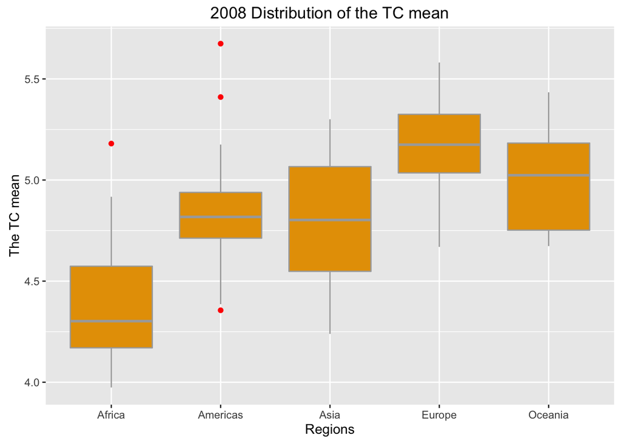

```r
ggplot(aes(x = dtm$Region, y = dtm$'2008'), data = dtm)+
  geom_boxplot(outlier.color='red', color="#A9A9A9", fill = '#E69F00')+
  xlab('Regions')+
  ylab('The TC mean')+
  labs(title = "2008 Distribution of the TC mean")
```

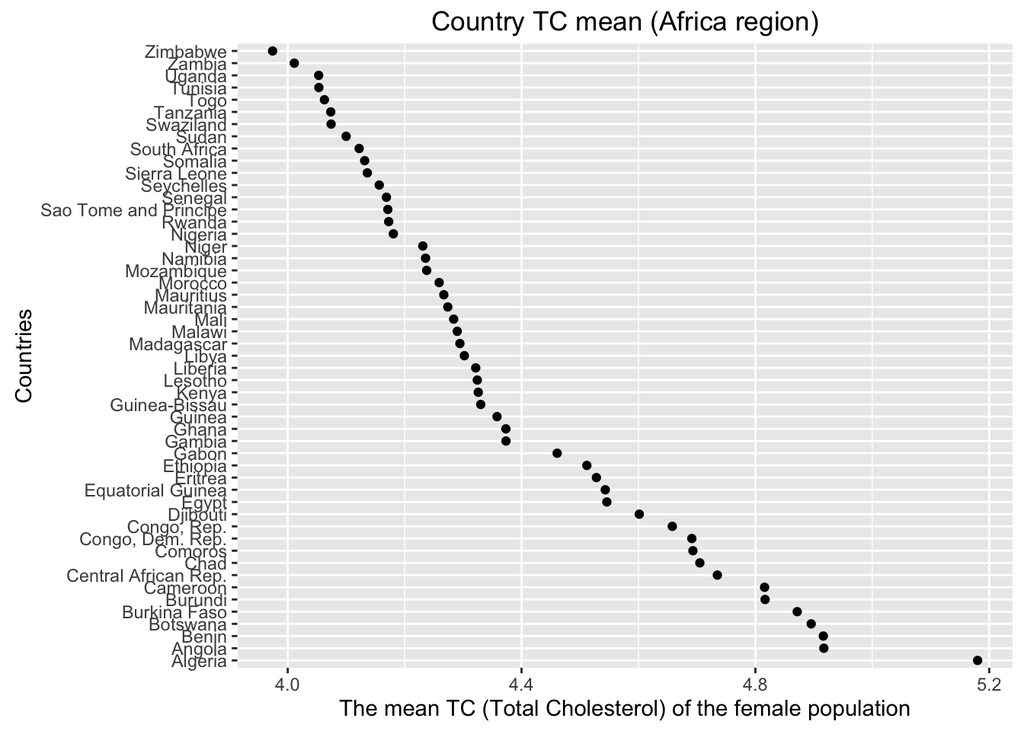

```r
region_africa_2008 <- region_africa[order(-region_africa$'2008'),]
qplot(region_africa_2008$'2008',region_africa[1:17]$Country)+
  xlab('The mean TC (Total Cholesterol) of the female population')+
  ylab('Countries')+
  labs(title = "Country TC mean (Africa region)")
```

### Resources

http://www.ats.ucla.edu/stat/r/faq/subset_R.htm

http://www.statmethods.net/

http://flowingdata.com/2015/02/18/loading-data-and-basic-formatting-in-r/

http://www.statmethods.net/input/datatypes.html

http://www.cookbook-r.com/Graphs/Facets_(ggplot2)/

http://docs.ggplot2.org/current/scale_continuous.html

http://flowingdata.com/2014/02/27/how-to-read-histograms-and-use-them-in-r/